# 第六章 信号与系统的时域和频域特性

## 理想低通滤波器的单位阶跃响应

$$\begin{aligned}
s(t) & =h(t)^{*} u(t) \\
& =\int_{-\infty}^{t} \frac{\omega_{c}}{\pi} \frac{\sin \omega_{c} \tau}{\omega_{c} \tau} d \tau=\frac{1}{\pi} \int_{-\infty}^{\omega_{c} t} \frac{\sin x}{x} d x \\
& =\frac{1}{\pi} \int_{-\infty}^{0} \frac{\sin x}{x} d x+\frac{1}{\pi} \int_{0}^{\omega_{c} t} \frac{\sin x}{x} d x \\
& =-\frac{1}{\pi} \int_{0}^{-\infty} \frac{\sin x}{x} d x+\frac{1}{\pi} \int_{0}^{\omega_{c} t} \frac{\sin x}{x} d x
\end{aligned}$$

令 $\int_{0}^{x} \frac{\sin \tau}{\tau} d \tau=\operatorname{Si}(x)$ ——正弦积分

由于

$$\begin{aligned}
& x \rightarrow \infty, \operatorname{Si}(x) \rightarrow \frac{\pi}{2} ; \quad x \rightarrow-\infty, \operatorname{Si}(x) \rightarrow-\frac{\pi}{2} \\
& s(t)=-\frac{1}{\pi} \operatorname{Si}(-\infty)+\frac{1}{\pi} \operatorname{Si}\left(\omega_{c} t\right)=\frac{1}{2}+\frac{1}{\pi} \operatorname{Si}\left(\omega_{c} t\right)
\end{aligned}$$

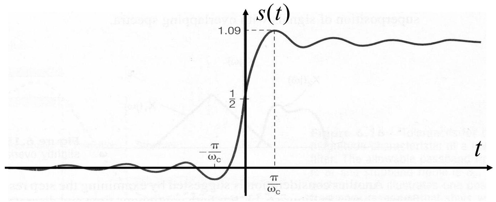

## 如果理想低通滤波器具有线性相位特性，则

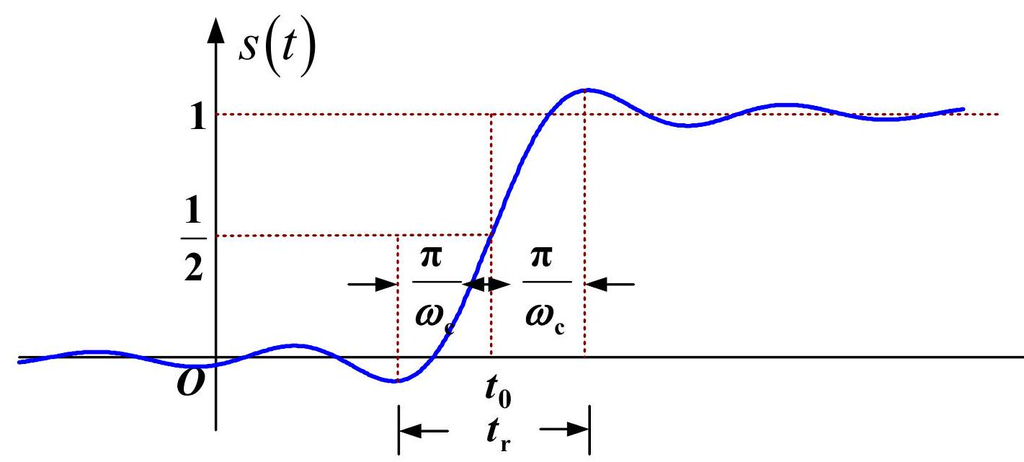

最大值位置：$t_{0}+\frac{\pi}{\omega_{c}}$ 最小值位置：$t_{0}-\frac{\pi}{\omega_{c}}$ $t t_{0}$ 为系统延迟时间 1．上升时间 $t_{r}$ ：输出由最小值到最大值所经历的时间

$$t_{\mathrm{r}}=2 \cdot \frac{\pi}{\omega_{\mathrm{c}}}=\frac{1}{B} \quad B=\frac{\omega_{\mathrm{c}}}{2 \pi}=f_{\mathrm{c}}$$

$\boldsymbol{B}$ 是将角频率折合为频率的滤波器带宽（截止频率）。 2．阶跃响应的上升时间 $t_{r}$ 与滤波器的截止频率 $B$（带宽） 成反比 $B t_{\mathrm{r}}=1$ 。

对离散时间理想低通滤波器，相应有：

$$s(n)=\frac{1}{2}+\frac{1}{\pi} \operatorname{Si}\left(\omega_{c} n\right)$$

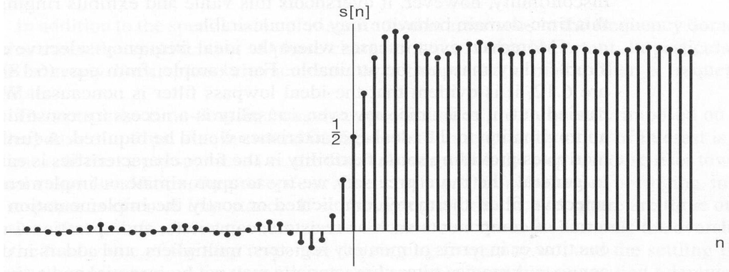

从理想滤波器的时域特性可以看出：

1．理想滤波器是非因果系统。因而是物理不可实现的；

2．尽管从频域滤波的角度看，理想滤波器的频率特性是最佳的。但它们的时域特性并不是最佳的。 $h(t)$或 $h(n)$ 都有起伏、旁瓣、主瓣，这表明理想滤波器的时域特性与频域特性并不兼容。

3．在工程应用中，当要设计一个滤波器时，必须对时域特性和频域特性作出恰当的折中。

## 目录

- 1. 傅里叶变换的模和相位表示
- 2. 线性时不变系统频率响应的模和相位表示
- 3. 理想频率选择性滤波器的时域特性
- **4. 非理想频率选择性滤波器的时域特性**
- 5. 一阶与二阶连续时间系统
- 6. 一阶与二阶离散时间系统
- 7. 系统的时域和频域分析实例

## 6.4 非理想滤波器（The Nonideal Filters）

由于理想滤波器是物理不可实现的，工程应用中就必须寻找一个物理可实现的频率特性去逼近理想特性，这种物理可实现的系统就称为非理想滤波器。

对理想特性逼近得越精确，实现时付出的代价越大，系统的复杂程度也越高。

非理想滤波器的频率特性以容限方式给出。

| 理想滤波器特性 | 非理想滤波器特性 |
| --- | --- |
| 1．通带绝对平坦，通带 | 通带内允许有起伏， |
| 内衰减为零。 | 有一定衰减范围 $\pm \delta_{1}$ |
| 2．阻带绝对平坦，阻带 | 阻带内允许有起伏， |
| 内衰减为 $\infty$ | 有一定衰减范围 $\delta_{2}$ |
| 3．无过渡带。 | 有一定的过渡带宽度 |

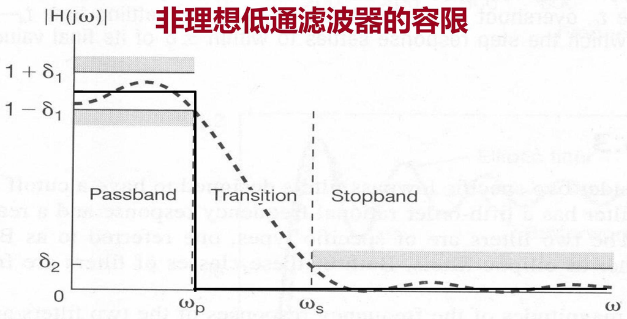

## 工程实际中常用的逼近方式有：

1．Butterworth滤波器： 通带、阻带均呈单调衰减，也称通带最平伏逼近； 2．Chebyshev滤波器： 通带等起伏阻带单调，或通带单调阻带等起伏； 3．Cauer滤波器：（椭圆函数滤波器） 通带、阻带均等起伏。 它们都从幅频特性出发逼近理想低通的模特性。

## 从相位特性出发，逼近理想的线性相位特性有

1．Bassel滤波器： 群时延最平伏逼近； 2．包络时延Chebyshev滤波器： 包络时延等起伏逼近； 3．Gauss滤波器。

对同一种滤波器，阶数越高，对理想特性逼近得越好，过渡带越窄，但付出的代价是系统越复杂。

对同样阶数的滤波器，从 Butterworth $\_\_\_\_$ Chebyshev ⟶Cauer，其幅频特性逼近得越来越 好，但阶跃响应的起伏、超量和振荡也越厉害（体现了系统频域特性与时域特性的不兼容）。系统的复杂程度也越来越高，相应地，实现系统所付出的代价也越来越大。

## 5阶Butterworth滤波器与5阶Cauer滤波器的比较

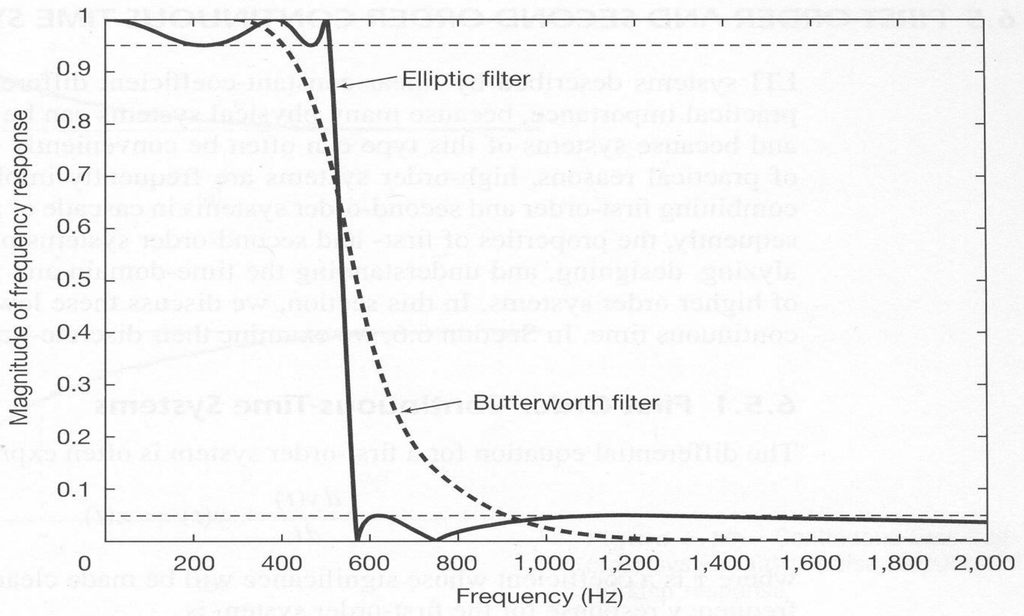

## 单位阶跃响应：

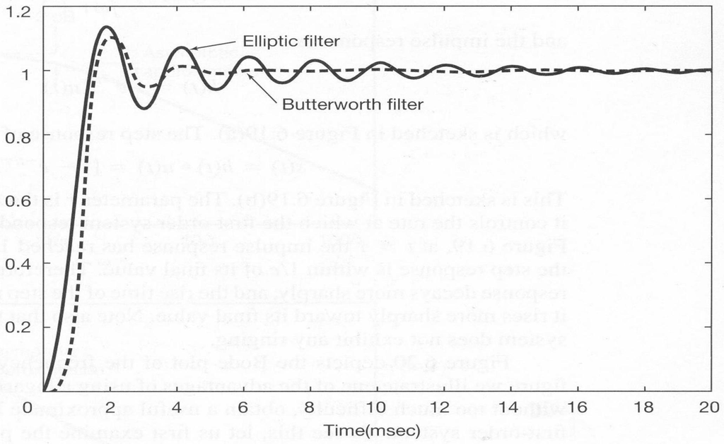

## 目录

- 1. 傅里叶变换的模和相位表示
- 2. 线性时不变系统频率响应的模和相位表示
- 3. 理想频率选择性滤波器的时域特性
- 4. 非理想频率选择性滤波器的时域特性
- **5. 一阶与二阶连续时间系统**
- 6. 一阶与二阶离散时间系统
- 7. 系统的时域和频域分析实例

## 6.5 一阶与二阶连续时间系统

## （First－Order and Second－Order Continuous－ Time Systems）

对由LCCDE描述的连续时间LTI系统，其频率响应为：

$$H(j \omega)=\frac{\sum_{k=0}^{M} b_{k}(j \omega)^{k}}{\sum_{k=0}^{N} a_{k}(j \omega)^{k}}=\frac{B(j \omega)}{A(j \omega)}$$

其中：$a_{k} 、 b_{k}$ 均为实常数。

此时，可通过对 $B(j \omega)$ 因式分解，将其表示成若干个一阶或二阶有理函数的连乘；或者通过部分分式展开，表示成若干个一阶或二阶有理函数相加。

这表明：由LCCDE描述的LTI系统可以看成由若干个一阶或二阶系统通过级联或并联构成。因此，一阶和二阶系统是构成任何系统的基本单元。掌握一阶和二阶系统的分析方法就尤为重要。

一．一阶系统：

模型：$\tau \frac{d y(t)}{d t}+y(t)=x(t) \quad H(j \omega)=\frac{1}{j \omega \tau+1}$ 1．时域特性：$h(t)=\frac{1}{\tau} e^{-\frac{t}{\tau}} u(t) \quad \tau$ ——时间常数

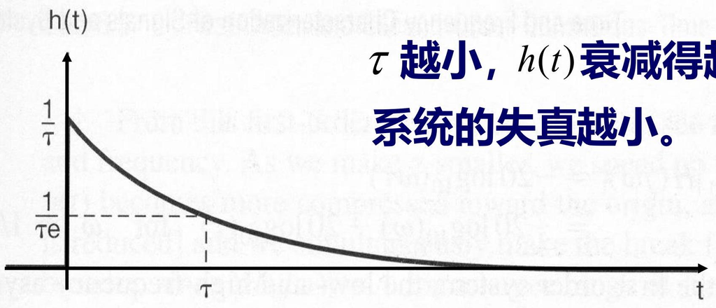

$$s(t)=h(t) * u(t)=\left(1-e^{-\frac{t}{\tau}}\right) u(t)$$

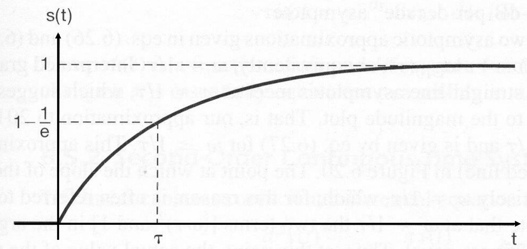

可以看出：$\tau$ 越小，$s(t)$ 上升得越快，系统失真越小。

2．一阶系统的Bode图：

$$20 \lg |H(j \omega)|=-10 \lg \left[1+(\omega \tau)^{2}\right]$$

$$H(j \omega)=\frac{1}{j \omega \tau+1}$$

$$20 \lg |H(j \omega)| \approx-20 \lg \omega \tau=-20 \lg \omega-20 \lg \tau$$

在对数坐标系下，它是一条直线，斜率为每 10 倍频程－20dB。可见，一阶系统的Bode图有两条直线型渐近线。 $\quad \omega=1$ 称为折断频率。

当 $\omega=$ 时，准确的对数模为

$$20 \lg |H(j \omega)|=-10 \lg 2 \mathrm{~B}-3 \mathrm{~dB}$$

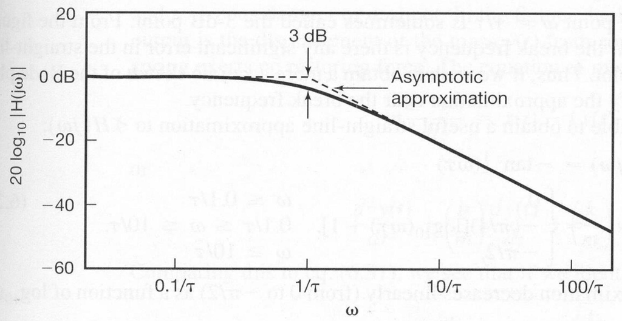

## 将其折线化可得相位特性的直线型渐近线：

$$\mathrm{R} H(j \omega)= \begin{cases}0, & \omega \leq 0.1 / \tau \\ -\frac{\pi}{4}[\lg \omega \tau+1], & \frac{0.1}{\tau} \leq \omega \leq \frac{10}{\tau} \\ -\frac{\pi}{2}, & \omega \geq 10 / \tau\end{cases}$$

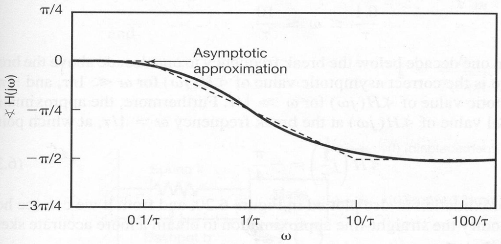

## 二．二阶系统：

模型：$\frac{d^{2} y(t)}{d t^{2}}+2 \zeta \omega_{n} \frac{d y(t)}{d t}+\omega_{n}{ }^{2} y(t)=\omega_{n}{ }^{2} x(t)$

如：对RLC串联谐振电路

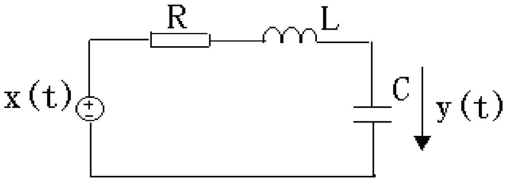

可列出电路方程

$$y^{\prime \prime}(t)+\frac{R}{L} y^{\prime}(t)+\frac{1}{L C} y(t)=\frac{1}{L C} x(t)$$

$$\zeta=\frac{R}{2} \sqrt{\frac{C}{L}}$$

考察由弾簧、阻尼器、质量M组成的减震系统

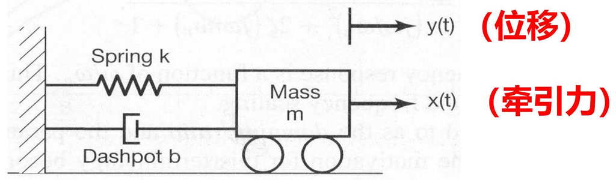

分析受力

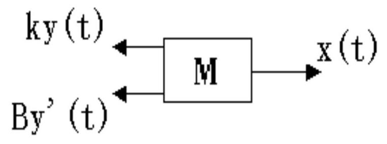

可列出方程

$$M \frac{d^{2} y(t)}{d t^{2}}=x(t)-k y(t)-B y^{\prime}(t)$$

即 $\frac{d^{2} y(t)}{d t^{2}}+\frac{B}{M} \frac{d y(t)}{d t}+\frac{k}{M} y(t)=\frac{k}{M} \hat{x}(t)$ 其中 $\hat{x}(t)=\frac{1}{k} x(t) \quad$ 显然，若 $\omega_{n}^{2}=k / M$ $\zeta=\frac{B}{2 \sqrt{k M}}$ 则方程就成为标准形式。 由二阶系统的方程可得系统的频率响应：

$$H(j \omega)=\frac{\omega_{n}^{2}}{(j \omega)^{2}+2 \zeta \omega_{n}(j \omega)+\omega_{n}^{2}}=\frac{1}{\left(j \frac{\omega}{\omega_{n}}\right)^{2}+2 \zeta\left(j \frac{\omega}{\omega_{n}}\right)+1}$$

$\zeta$ 称为阻尼系数，$\omega_{n}$ 称为无阻尼自然频率

1．时域特性—冲激响应

$$H(j \omega)=\frac{\omega_{n}^{2}}{(j \omega)^{2}+2 \zeta \omega_{n}(j \omega)+\omega_{n}^{2}}=\frac{\omega_{n}^{2}}{\left(j \omega-c_{1}\right)\left(j \omega-c_{2}\right)}$$

（1）$\zeta=0$ 时，$c_{1}=c_{2}^{*}=$ 系统处于无阻尼状态。

$$H(j \omega)=\frac{\omega_{n}^{2}}{(j \omega)^{2}+\omega_{n}^{2}} \quad h(t)=\omega_{n} \sin \left(\omega_{n} t\right) u(t)$$

$$\begin{aligned}
& H(j \omega)=\frac{M}{j \omega-c_{1}}-\frac{M}{j \omega-c_{2}} \quad M=\frac{\omega_{n}}{2 j \sqrt{1-\zeta^{2}}} \\
& h(t)=\frac{\omega_{n}}{\sqrt{1-\zeta^{2}}} e^{-\zeta \omega_{n} t} \sin \left(\omega_{n} \sqrt{1-\zeta^{2}} t\right) u(t)
\end{aligned}$$

（3）当 $\zeta$ 时，$c_{1}=c_{2}=-\omega_{n}$ 系统处于临界阻尼状态。

$$\begin{aligned}
& H(j \omega)=\frac{\omega_{n}^{2}}{\left(j \omega-c_{1}\right)^{2}}=\frac{\omega_{n}^{2}}{\left(j \omega+\omega_{n}\right)^{2}} \\
& h(t)=\omega_{n}^{2} t e^{-\omega_{n} t} u(t)
\end{aligned}$$

（4）$\zeta>1$ 时，$c_{1}$ 为实数根，系统为过阻尼状态；

$$\begin{aligned}
& c_{1,2}=-\zeta \omega_{n} \pm \omega_{n} \sqrt{\zeta^{2}-1} \\
& H(j \omega)=\frac{M}{j \omega-c_{1}}-\frac{M}{j \omega-c_{2}} \quad M=\frac{\omega_{n}}{2 \sqrt{\zeta^{2}-1}} \\
& h(t)=M\left[e^{c_{1} t}-e^{c_{2} t}\right] u(t)
\end{aligned}$$

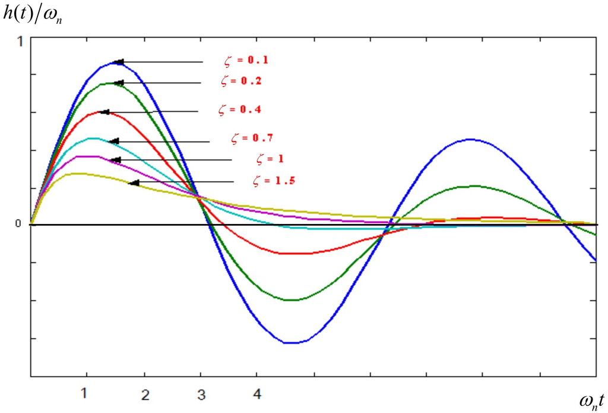

## 1．时域特性—阶跃响应

当 $\zeta$ 肘

$$s(t)=h(t) * u(t)=\left[1+M\left(\frac{e^{c_{1} t}}{c_{1}}-\frac{e^{c_{2} t}}{c_{2}}\right)\right] u(t)$$

当 $\zeta$ 时，$\quad c_{1}=c_{2}=-\omega_{n}$

$$s(t)=h(t) * u(t)=\left[1-e^{-\omega_{n} t}-\omega_{n} t e^{-\omega_{n} t}\right] u(t)$$

2．频率特性：

$$\begin{gathered}
|H(j \omega)|=\frac{1}{\sqrt{\left[1-\left(\frac{\omega}{\omega_{n}}\right)^{2}\right]^{2}+4 \zeta^{2}\left(\frac{\omega}{\omega_{n}}\right)^{2}}} \\
20 \lg |H(j \omega)|=-10 \lg \left\{\left[1-\left(\frac{\omega}{\omega_{n}}\right)^{2}\right]^{2}+4 \zeta^{2}\left(\frac{\omega}{\omega_{n}}\right)^{2}\right\}
\end{gathered}$$

当 $\omega=$ 时，$\quad 20 \lg |H(j \omega)| \approx 0 \mathrm{~dB}$ 当 $\omega$ ？时，

$$\begin{aligned}
20 \lg |H(j \omega)| & \approx-10 \lg \left(\frac{\omega}{\omega_{n}}\right)^{4}=-40 \lg \frac{\omega}{\omega_{n}} \\
& =-40 \lg \omega+40 \lg \omega_{n}
\end{aligned}$$

## 在对数坐标中可用两条直线表示。一条是低频段的

0 dB 线，一条是高频段的斜率为 $-40 \mathrm{~dB} / \mathrm{dec}$ 的直线。在 $\omega=$ 处，两条渐进线相交，因此 称为二阶系统的折转频率。 $\omega=\omega_{n}$ 时，准确的对数模为：

$$20 \lg |H(j \omega)|=-20 \lg 2 \zeta$$

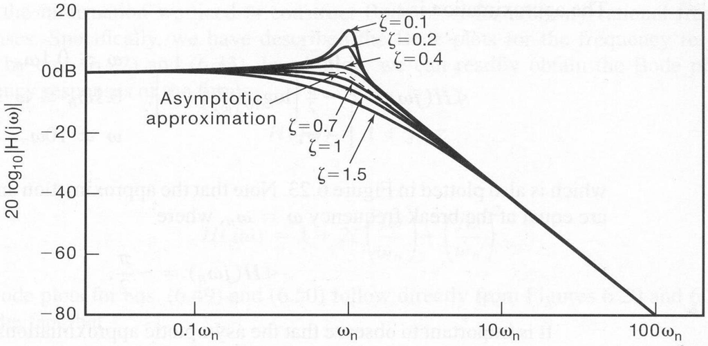

$$\begin{aligned}
20 \lg |H(j \omega)| & =-10 \lg \left[1+\left(4 \zeta^{2}-2\right)\left(\frac{\omega}{\omega_{n}}\right)^{2}+\left(\frac{\omega}{\omega_{n}}\right)^{4}\right] \\
& =-10 \lg \left\{\left[\left(\frac{\omega}{\omega_{n}}\right)^{2}-\left(1-2 \zeta^{2}\right)\right]^{2}+1-\left(1-2 \zeta^{2}\right)^{2}\right\}
\end{aligned}$$

$$Q=\frac{1}{2 \zeta}$$

## 相位特性：

$$\begin{array}{ll}
\mathrm{R} H(j \omega)=-\tan ^{-1} \frac{2 \zeta \frac{\omega}{\omega_{n}}}{1-\left(\frac{\omega}{\omega_{n}}\right)^{2}} & \omega=\omega_{n} \text { 时 } \omega \rightarrow 0, \mathrm{R} H(j \omega) \rightarrow 0 \\
\omega=\omega_{n} \text { 时 } \mathrm{R} H(j \omega)=-\frac{\pi}{2} \\
\omega \rightarrow \infty \text { 时 } \mathrm{R} H(j \omega) \rightarrow-\pi
\end{array}$$

可将其用折线近似为：

$$\mathrm{R} H(j \omega)= \begin{cases}0, & \omega \leq 0.1 \omega_{n} \\ -\frac{\pi}{2}\left[\lg \frac{\omega}{\omega_{n}}+1\right], & 0.1 \omega_{n} \leq \omega \leq 10 \omega_{n} \\ -\pi, & \omega \geq 10 \omega_{n}\end{cases}$$

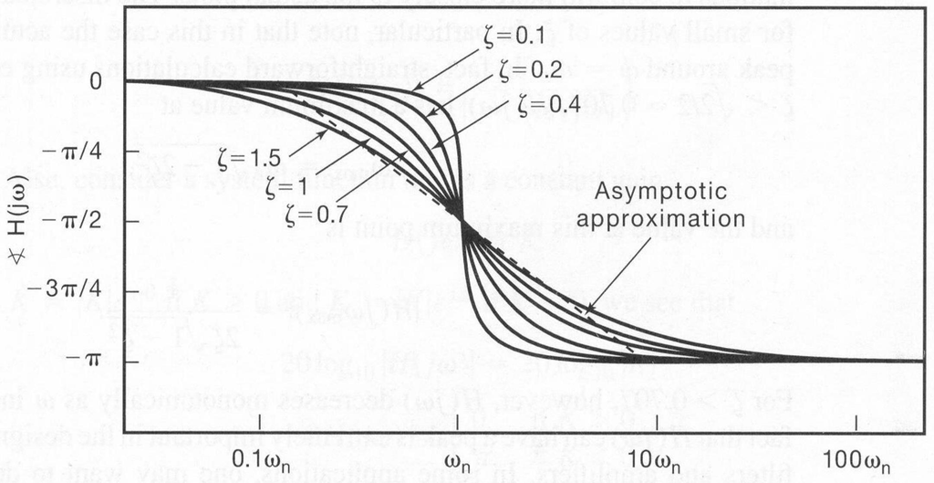

## 可见 越小，相位的非线性越严重。

三．有理型频率响应的Bode图：

$$\begin{aligned}
\text { 对于 } \hat{H}(j \omega) & =j \omega \tau+1 \\
\hat{H}(j \omega) & =\left(\frac{j \omega}{\omega_{n}}\right)^{2}+2 \zeta\left(\frac{j \omega}{\omega_{n}}\right)+1
\end{aligned}$$

这种频率特性的因子，与一阶、二阶系统的情况相比，其 $H$（存在倒量关系。即

$$\begin{gathered}
20 \lg |\hat{H}(j \omega)|=20 \lg \left|\frac{1}{H(j \omega)}\right|=-20 \lg |H(j \omega)| \\
\operatorname{R} \hat{H}(j \omega)=-\mathrm{R} H(j \omega)
\end{gathered}$$

## 6.6 一阶与二阶离散时间系统

（First－Order and Second－Order Discrete－Time Systems）

## 一．一阶系统：

系统的数学模型：

$$y(n)-a y(n-1)=x(n) \quad|a|<1$$

由差分方程可得系统的频率响应：

$$H\left(e^{j \omega}\right)=\frac{1}{1-a e^{-j \omega}}$$

## 1．时域特性：

对频率响应做傅立叶反变换可得：

$$h(n)=a^{n} u(n)$$

系统的单位阶跃响应为：

$$s(n)=\sum_{k=-\infty}^{n} h(k)=\sum_{k=0}^{n} a^{k}=\frac{1-a^{n+1}}{1-a} u(n)$$

据此可作出不同参数情况下系统的单位脉冲响应和单位阶跃响应：

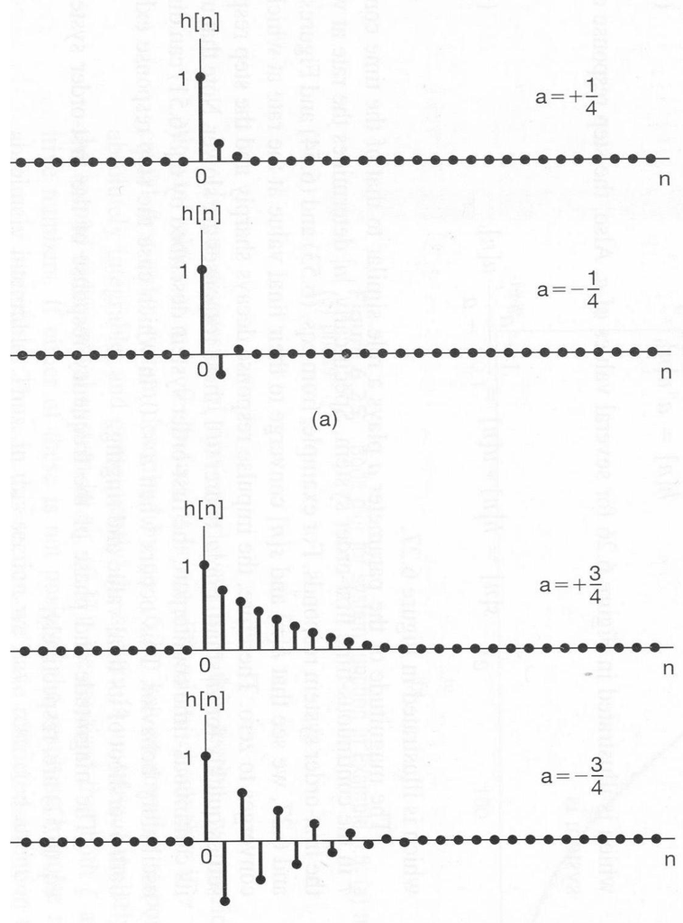

(c)

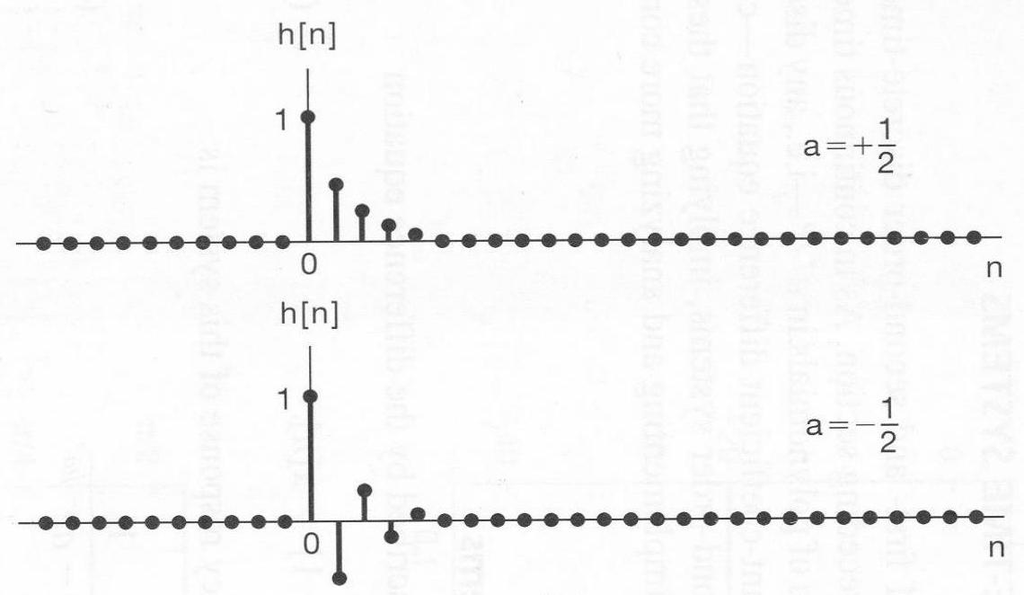

(b)

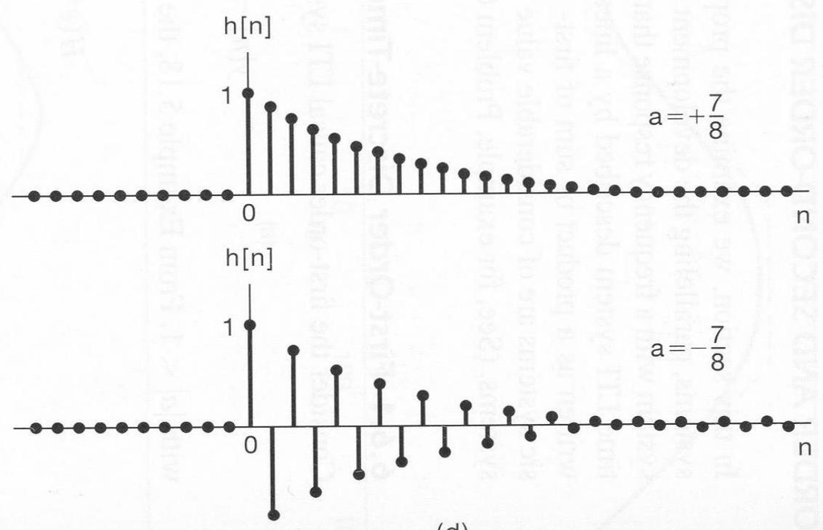

(d)

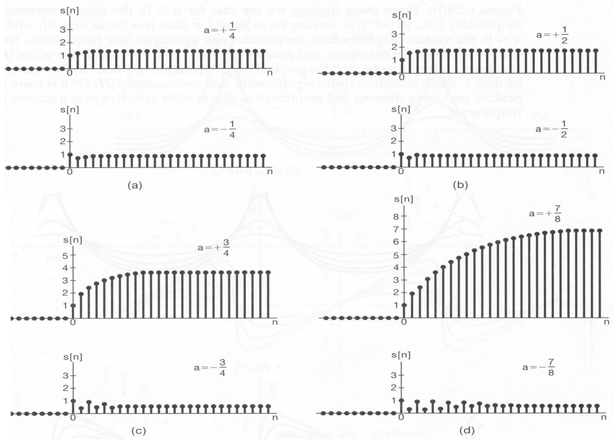

## 由图可以看出：

－当 $a>0$ 时，随着 $a$ 的增大，系统的单位脉冲响应单调衰减得越来越慢。单位阶跃响应单调上升得越来越慢。 －当 $a<0$ 时，系统的单位脉冲响应和单位阶跃响应都存在振荡。 $|a|$ 越大，振荡的持续期越长；单位脉冲响应衰减得越慢，单位阶跃响应上升得越慢。

2．频域特性： 由系统的频率响应可以得出：

$$\begin{aligned}
& \left|H\left(e^{j \omega}\right)\right|=\frac{1}{\sqrt{1+a^{2}-2 a \cos \omega}} \\
& \operatorname{RH}\left(e^{j \omega}\right)=-\tan ^{-1} \frac{a \sin \omega}{1-a \cos \omega}
\end{aligned}$$

据此可作出不同参数情况下一阶系统的幅频特性和相频特性：

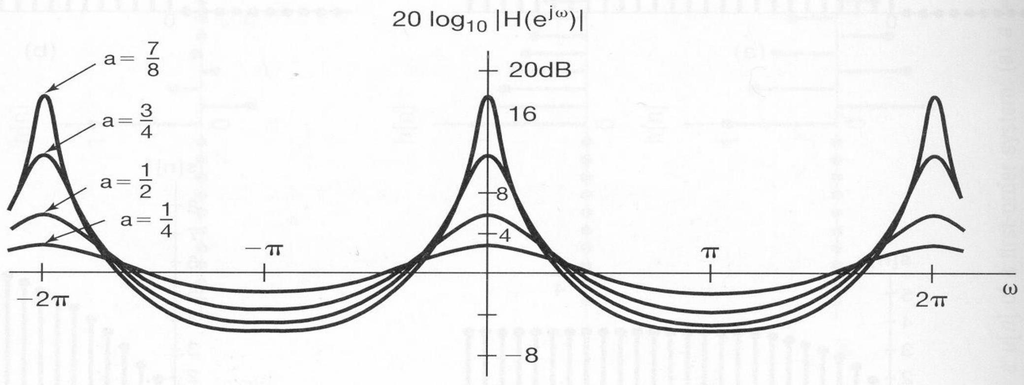

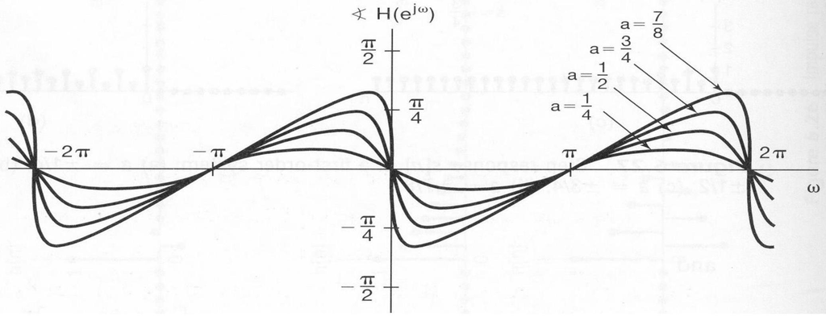

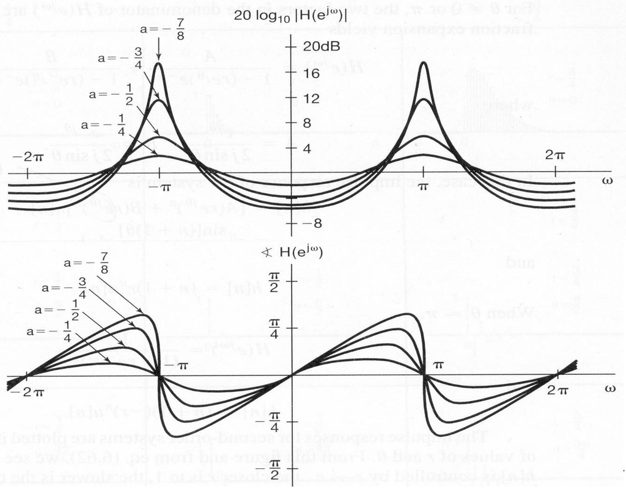

## 二．二阶系统：

数学模型：$y(n)-2 r \cos \theta y(n-1)+r^{2} y(n-2)=x(n)$ 其中 $0<r<1, \quad 0 \leq \theta \leq \pi$ ，

$$H\left(e^{j \omega}\right)=\frac{1}{1-2 r \cos \theta e^{-j \omega}+r^{2} e^{-j 2 \omega}}=\frac{1}{\left[1-r e^{j \theta} e^{-j \omega}\right]\left[1-r e^{-j \theta} e^{-j \omega}\right]}$$

$\theta \neq 0$ 或 $\pi$ 时，$H\left(\right.$ 有两个不同的极点 $v e^{j \theta} r e^{-j \theta}$

$$\begin{aligned}
& H\left(e^{j \omega}\right)=\frac{A}{1-r e^{j \theta} e^{-j \omega}}+\frac{B}{1-r e^{-j \theta} e^{-j \omega}} \\
& \text { 其中 } \quad A=\frac{e^{j \theta}}{2 j \sin \theta} \quad B=\frac{-e^{-j \theta}}{2 j \sin \theta}
\end{aligned}$$

$h(n)=\left[A\left(r e^{j \theta}\right)^{n}+B\left(r e^{-j \theta}\right)^{n}\right] u(n)=r^{n} \frac{\sin (n+1) \theta}{\sin \theta} u(n) r$ 影响衰减速率，$\theta$ 影响振荡频率。 $h(n)$ 为指数衰减的正弦振荡。系统为欠阻尼状态。 $\theta=0$ 时，$H\left(e^{j \omega}\right)=\frac{1}{\left(1-r e^{-j \omega}\right)^{2}} \quad$ 系统为临界阻尼。 $h(n)=(n+1) r^{n} u(n) \quad h(n)$ 单调变化，无振荡。 $\theta=\pi$ 时，$\quad H\left(e^{j \omega}\right)=\frac{1}{\left(1+r e^{-j \omega}\right)^{2}}$ 系统为欠阻尼。 $h(n)=(n+1)(-r)^{n} u(n) \quad h(n)$ 振荡最剧烈。

## 系统的单位脉冲响应：

[output not shown]

[output not shown]

## 系统的单位阶跃响应：

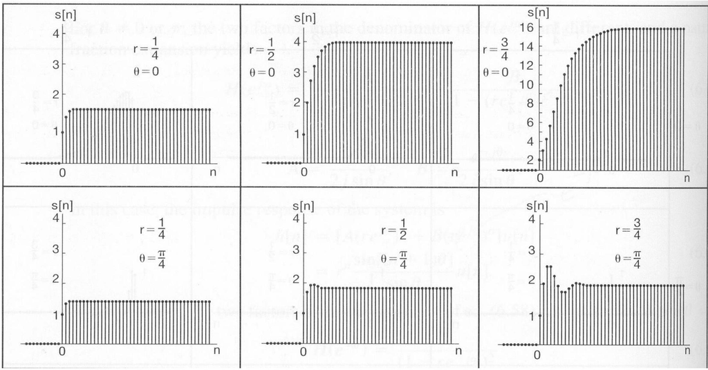

[output not shown]

## 由图可以看出：

1．当系统处于欠阻尼状态时，即 $0<\theta \leq \pi$ 时，系统的单位冲激响应和单位阶跃响应都存在振荡和超量。 $\theta$ 越接近 $\pi$ ，振荡的频率越高。

2．在欠阻尼状态下，$r$ 影响着单位冲激响应和单位阶跃响应的变化速率。 $r$ 越接近1，单位冲激响应衰减得越慢，单位阶跃响应上升得越慢，出现的振荡也越明显。

根据不同的 $\theta$ 和 $r$ 可作出系统的频率特性：

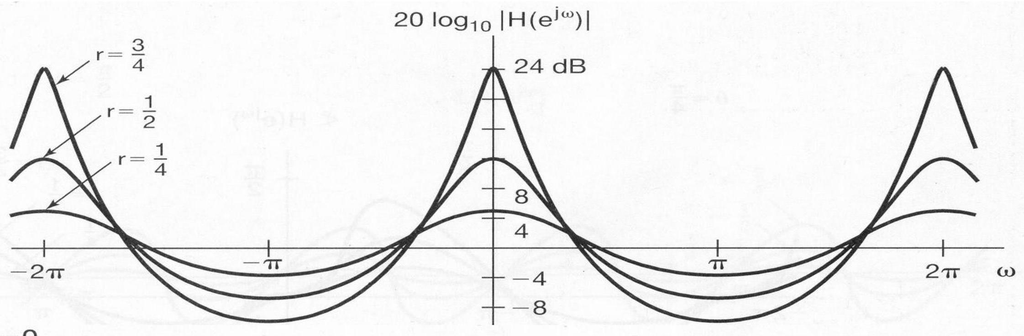

$$\theta=0$$

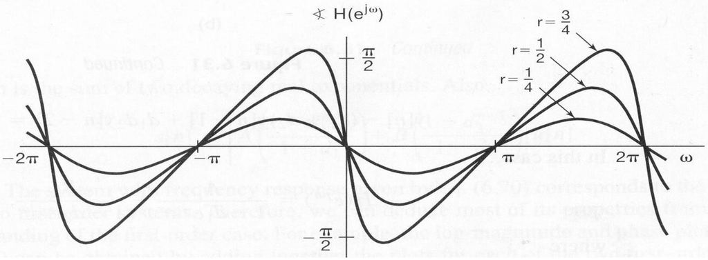

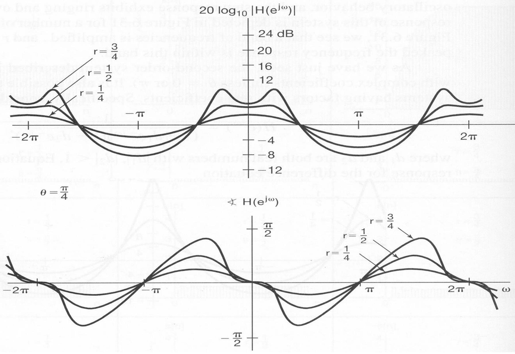

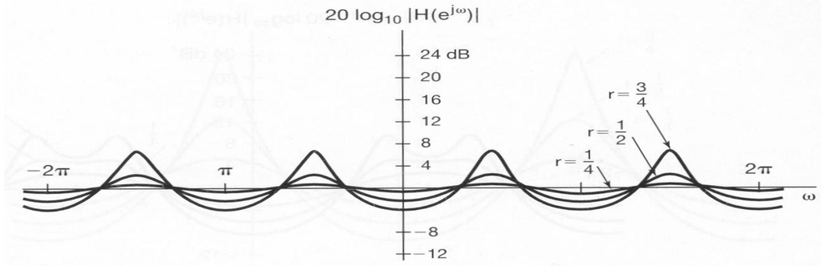

$$\theta=\frac{\pi}{2}$$

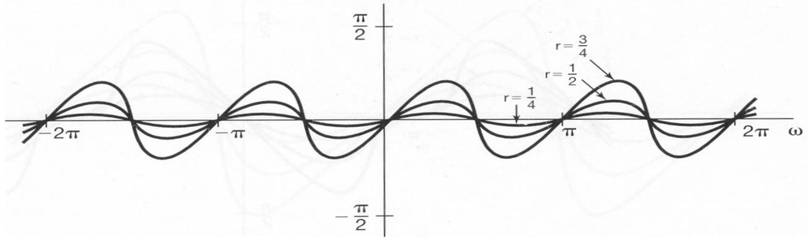

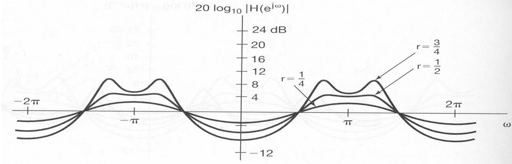

$$\theta=\frac{3 \pi}{4}$$

[figure not shown]

$$\begin{aligned}
& r=\frac{3}{4} \\
& r=\frac{1}{2} \\
& r=\frac{1}{4}
\end{aligned}$$

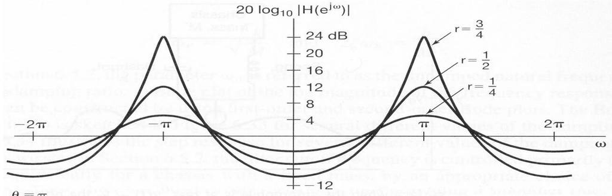

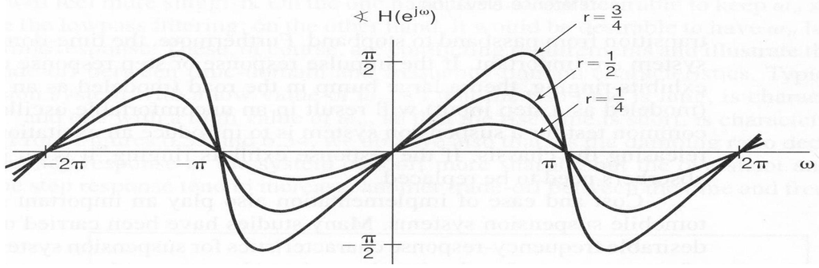

## 由图可以看出：

1．$r$ 越大，幅频特性的峰越尖锐，系统的带宽越窄；$r$ 越小，幅频特性越平坦，系统带宽越宽。

2．系统幅频特性的峰值总是出现在 $\theta$ 值的附近，随着 $\theta$ 从 $0: \pi$ 变化，系统经历了从低通特性 ⟶带通特性—高通特性的变化过程。

3．系统具有非线性相位特性。 总之：$\theta$ 影响系统频响的峰值位置，$r$ 影响峰值的大小，其作用分别类似于连续系统的 $\omega_{n}$ 和 $\zeta$

二阶系统也可以处在过阻尼状态，此时系统有两个实数极点。将 $H\left(e^{j \omega}\right)$ 展开成部分分式有：

$$H\left(e^{j \omega}\right)=\frac{1}{\left(1-d_{1} e^{-j \omega}\right)\left(1-d_{2} e^{-j \omega}\right)}=\frac{A}{\left(1-d_{1} e^{-j \omega}\right)}+\frac{B}{\left(1-d_{2} e^{-j \omega}\right)}$$

其中 $A=\frac{d_{1}}{d_{1}-d_{2}}$

$$B=\frac{d_{2}}{d_{2}-d_{1}}$$

此时相当于两个一阶系统级联。当 $d_{1}>0, d_{2}>0$时，系统为过阻尼状态；当 $d_{1}<0, d_{2}<0$ 时，系统为欠阻尼状态。其他情况，系统状态 将取决于绝对值大的极点（主时间常数）是正值还是负值。

## 6.7 系统的时域分析与频域分析举例

## Examples of Time－and Frequency－Domain Analysis of Systems

一．汽车减震系统： 系统模型为：

$$M \frac{d^{2} y(t)}{d t^{2}}+b \frac{d y(t)}{d t}+k y(t)=k x(t)+b \frac{d x(t)}{d t}$$

类似于前面讨论过的二阶系统，其中

$$\omega_{n}=\sqrt{\frac{k}{M}} \quad 2 \zeta \omega_{n}=\frac{b}{M}$$

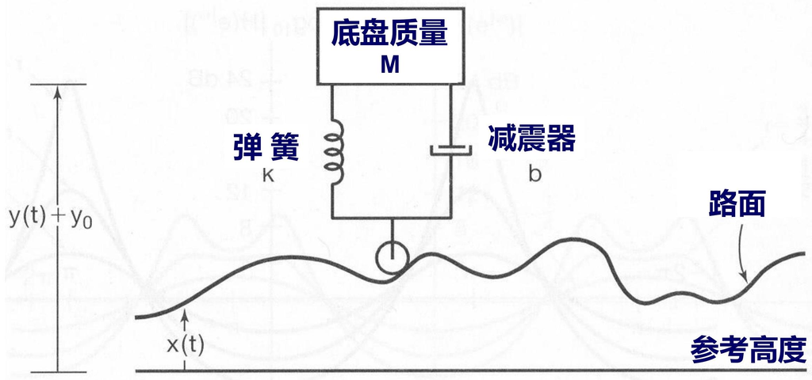

对系统的时域特性和频域特性综合折中考虑，是工程应用中很重要的问题。

二．FIR滤波器： 离散时间滤波器可以分为IIR和FIR两大类。 考察如下的动平均滤波器：

$$y(n)=\frac{1}{N+M+1} \sum_{k=-N}^{M} x(n-k)$$

它是一个FIR系统，其频率响应为：

$$H\left(e^{j \omega}\right)=\frac{1}{N+M+1} \sum_{k=-N}^{M} e^{-j \omega k}=\frac{1}{N+M+1} \frac{\sin \frac{N+M+1}{2} \omega}{\sin \frac{\omega}{2}} e^{j \frac{N-M}{2} \omega}$$

更一般的情况，可加权的动平均滤波器可表示为：

$$y(n)=\sum_{k=-N}^{M} b_{k} x(n-k)$$

选择不同的加权序列 $b_{k}$ ，即可改变滤波器的特性。

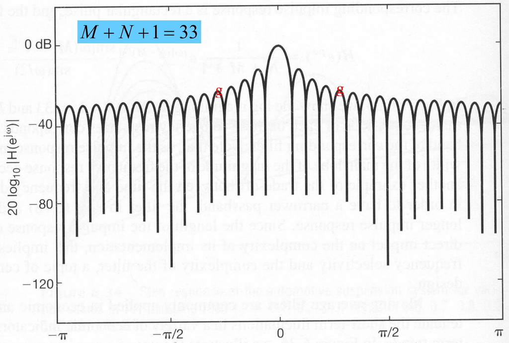

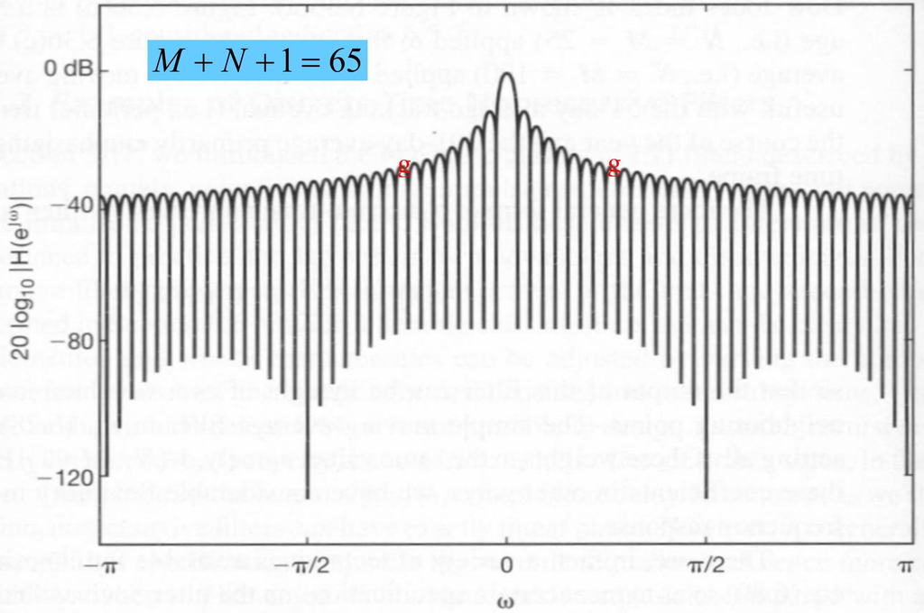

$$y(n)=\sum_{k=-N}^{N} h_{k} x(n-k) \quad h(n)= \begin{cases}\frac{\sin (2 \pi n / 33)}{\pi n}, & |n| \leq 32 \\ 0, & |n|>32\end{cases}$$

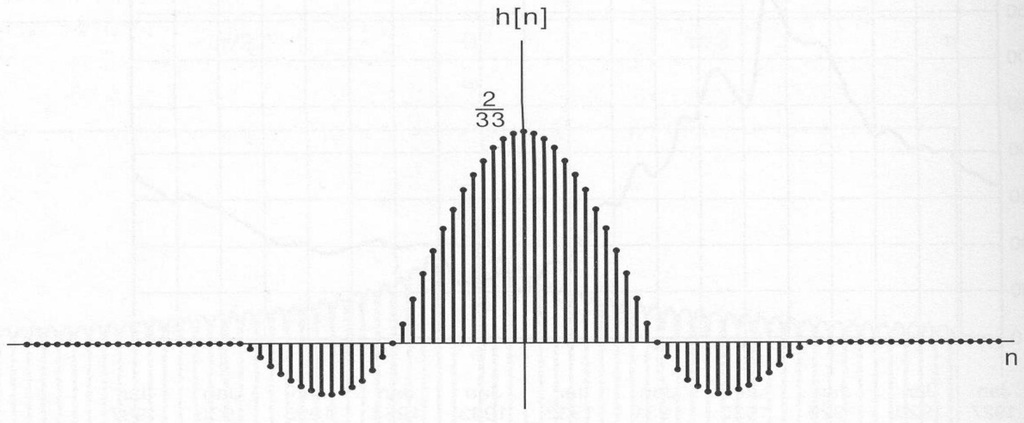

（a）

## 该FIR滤波器的幅频特性（对数模）：

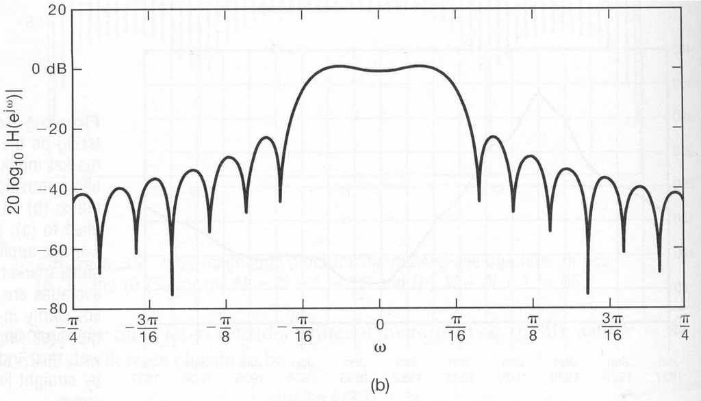

## 6.8 小结 Summary

＊从傅里叶变换的模和相位表示出发，研究了信号在传输中发生失真的原因和失真的种类。建立了信号传输的不失真条件。 ＊介绍了滤波与滤波器的基本概念，理想频率选择性滤波器的频率特性和时域特性，理想滤波器的不可实现性，非理想滤波器的概念及工程中常用的逼近方式。 ＊讨论了连续时间和离散时间一阶、二阶系统的时域和频域特性的分析方法，及连续时间一阶、二阶系统Bode图的绘制。 ＊以汽车减震系统和动平均FIR滤波器为例，简单介绍了在工程应用中时域－频域、幅频－相频特性要折衷权衡考虑的思想。

## 目录

- 1. 傅里叶变换的模和相位表示
- 2. 线性时不变系统频率响应的模和相位表示
- 3. 理想频率选择性滤波器的时域特性
- 4. 非理想频率选择性滤波器的时域特性
- 5. 一阶与二阶连续时间系统
- 6. 一阶与二阶离散时间系统
- **7. 系统的时域和频域分析实例**

## 目录

1. 傅里叶变换的幅度–相位表示
2. 不确定性原理
3. 傅里叶表示之间的关系

## 不确定性原理

设连续时间信号 $x \in L_{2}(\mathbb{R})$，其傅里叶变换为 $X=\mathcal{F}\{x\} \in L_{2}(\mathbb{R})$。定义时域与频域中的归一化功率密度为

$$p(t)=\frac{|x(t)|^{2}}{\int_{\mathbb{R}}|x(\tau)|^{2} d \tau}, \quad P(\omega)=\frac{|X(j \omega)|^{2}}{\int_{\mathbb{R}}|X(j \theta)|^{2} d \theta}$$

注：$p$ 与 $P$ 可以像量子力学中那样解释为概率密度。 从如下意义上说，$x$ 与 $X$ 分别以 $t_{0}$ 和 $\omega_{0}$ 为中心：

$$t_{0}=\int_{\mathbb{R}} t p(t) d t, \quad \omega_{0}=\int_{\mathbb{R}} \omega P(\omega) d \omega$$

“标准差”用于衡量能量相对于中心位置的分散程度

$$\Delta t=\left[\int_{\mathbb{R}}\left(t-t_{0}\right)^{2} p(t) d t\right]^{\frac{1}{2}}, \quad \Delta \omega=\left[\int_{\mathbb{R}}\left(\omega-\omega_{0}\right)^{2} P(\omega) d \omega\right]^{\frac{1}{2}}$$

## 不确定性原理

定理：若 $x(t) \in L_{2}(\mathbb{R})$，其傅里叶变换为 $X(j \omega)$，则有

$$\Delta t \Delta \omega \geq \frac{1}{2}$$

当且仅当 $x$ 为高斯函数时取等号。 事实上，还成立如下稍一般的关系：

$$D_{a}(x) D_{b}(X) \geq \frac{1}{2}\|x\|_{2} \cdot\|X\|_{2}$$

其中，对任意 $g \in L_{2}(\mathbb{R})$ 以及 $a \in \mathbb{R}$，

$$D_{a}(g)=\left[\int_{\mathbb{R}}(\xi-a)^{2}|g(\xi)|^{2} d \xi\right]^{\frac{1}{2}}$$

注：粗略地说，一个信号不可能同时在时域和频域都高度集中；短脉冲往往对应较宽带宽，而窄带信号通常持续时间较长。

## 不确定性原理的证明

先假设 $a=b=0$。

$$D_{0}(X)=\left[\int_{\mathbb{R}} \omega^{2}|X(j \omega)|^{2} d t\right]^{\frac{1}{2}}=\left[\int_{\mathbb{R}}|j \omega X(j \omega)|^{2} d \omega\right]^{\frac{1}{2}}$$

由于 $x^{\prime}(t) \stackrel{\mathcal{F}}{\longleftrightarrow} j \omega X(j \omega)$，由 Parseval 恒等式可得

$$D_{0}(X)=\left[2 \pi \int_{\mathbb{R}}\left|x^{\prime}(t)\right|^{2} d t\right]^{\frac{1}{2}}$$

由 Cauchy–Schwarz 不等式，

$$\begin{aligned}
D_{0}(x) D_{0}(X) & =\sqrt{2 \pi}\left[\int_{\mathbb{R}}|t x(t)|^{2} d t\right]^{\frac{1}{2}}\left[\int_{\mathbb{R}}\left|x^{\prime}(t)\right|^{2} d t\right]^{\frac{1}{2}} \\
& \geq \sqrt{2 \pi}\left|\int_{\mathbb{R}} t x^{*}(t) x^{\prime}(t) d t\right| \geq \sqrt{2 \pi}\left|\operatorname{Re} \int_{\mathbb{R}} t x^{*}(t) x^{\prime}(t) d t\right|
\end{aligned}$$

## 不确定性原理的证明

注意， $2 \operatorname{Re} \int_{\mathbb{R}} t x^{*}(t) x^{\prime}(t) d t=\int_{\mathbb{R}} t x^{*}(t) x^{\prime}(t) d t+\int_{\mathbb{R}} t x(t) \overline{x^{\prime}(t)} d t=\int_{\mathbb{R}} t d|x(t)|^{2}$ 对其分部积分可得

$$2 \operatorname{Re} \int_{\mathbb{R}} t x^{*}(t) x^{\prime}(t) d t=\left.t|x(t)|^{2}\right|_{-\infty} ^{\infty}-\int_{\mathbb{R}}|x(t)|^{2} d t$$

若 $D_{0}(x)=\infty$，则不等式显然成立，因此可设 $D_{0}(x)<\infty$。于是当 $t \rightarrow \infty$ 时，$t|x(t)|^{2} \rightarrow 0$。因此

$$D_{0}(x) D_{0}(X) \geq \frac{\sqrt{2 \pi}}{2}\|x\|_{2}^{2}=\frac{1}{2}\|x\|_{2} \cdot\|X\|_{2}$$

对于 $a,b \neq 0$ 的情形，注意到若定义 $y(t)=x(t+a) e^{-j b t} \stackrel{\mathcal{F}}{\longleftrightarrow} Y(j \omega)=X(j(\omega+b)) e^{j(\omega+b) a}$， 则有 $D_{a}(x)=D_{0}(y)$ 且 $D_{b}(X)=D_{0}(Y)$。$

目录

1. 傅里叶变换的幅度–相位表示
2. 不确定性原理
3. 傅里叶表示之间的关系

## 四种傅里叶表示

连续时间傅里叶级数（CTFS） $\hat{x}[k]=\frac{1}{T} \int_{T} x(t) e^{-j \frac{2 \pi}{T} k t} d t$ $x(t)=x(t+T)=\sum_{k \in \mathbb{Z}} \hat{x}[k] e^{j \frac{2 \pi}{T} k t}$ 离散时间傅里叶级数（DTFS） $\hat{x}[k]=\frac{1}{N} \sum_{n \in[N]} x[n] e^{-j \frac{2 \pi}{N} k n}$ $x[n]=x[n+N]=\sum_{k \in[N]} \hat{x}[k] e^{j \frac{2 \pi}{N} k n}$

连续时间傅里叶变换（CTFT） $X(j \omega)=\int_{\mathbb{R}} x(t) e^{-j \omega t} d t$ $x(t)=\frac{1}{2 \pi} \int_{\mathbb{R}} X(j \omega) e^{j \omega t} d \omega$ 离散时间傅里叶变换（DTFT） $X\left(e^{j \omega}\right)=\sum_{n \in \mathbb{Z}} x[n] e^{-j \omega n}$ $x[n]=\frac{1}{2 \pi} \int_{2 \pi} X\left(e^{j \omega}\right) e^{j \omega n} d \omega$

DFT 可以看作 DTFS 的一个周期。

四种傅里叶表示之间的关系

| 表示 | 时间域自变量 | 时间域信号 | 频域自变量 | 频域表示 |
| --- | --- | --- | --- | --- |
| CTFS | 连续 | 周期 | 离散 | 非周期 |
| CTFT | 连续 | 非周期 | 连续 | 非周期 |
| DTFS | 离散 | 周期 | 离散 | 周期 |
| DTFT | 离散 | 非周期 | 连续 | 周期 |

观察结论

- 一个域中“周期”，对应另一个域中“离散”；
- 一个域中的采样离散化，对应另一个域中的周期延拓；
- 一个域中的插值连续化，对应另一个域中取出一个周期。

四种傅里叶表示之间的关系

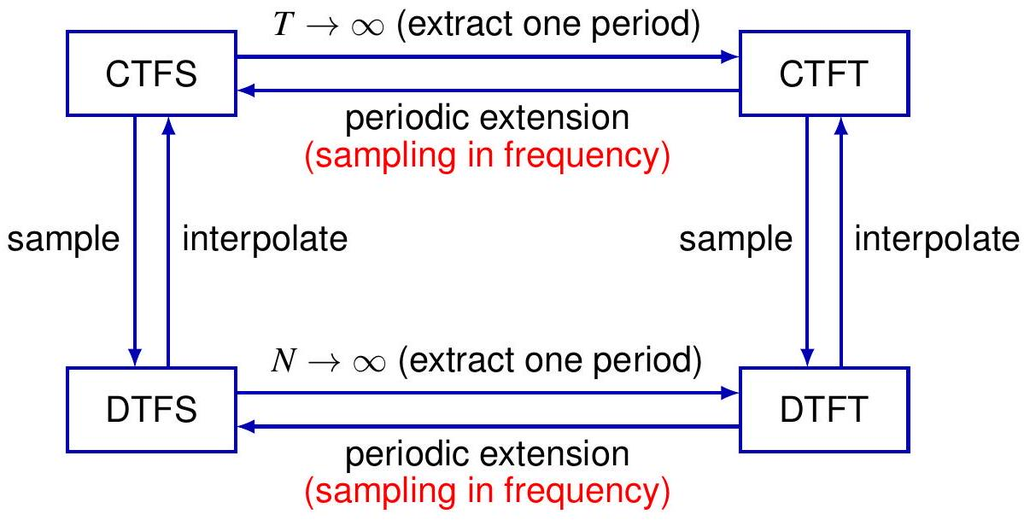

注：上述对应关系在某些情形下需要满足额外条件。

## 作业

# 第六章 信号与系统的时域和频域特性 完